# Predicting and Understanding the Risk of Myocardial Infarction and Coronary Heart Disease

# Introduction

This project is based on part of the data from the Framingham Heart Study, focusing on the risk factors for myocardial infarction (heart attack) and coronary heart disease (CHD).

## **Data Description**

- **Key Variables:**
  - Outcome Variable**:** `MI_FCHD` (1 = Event Occurred, 0 = No Event)
  - Predictors:
    - `CIGPDAY`: Cigarettes smoked per day
    - `SEX`: Gender
    - `AGE`: Age
    - `TOTCHOL`: Total Cholesterol
    - `SYSBP`: Systolic Blood Pressure
    - `DIABP`: Diastolic Blood Pressure
    - `BMI`: Body Mass Index

```r
library(tidyverse)
library(ggplot2)
library("mgcv")
library(glmtoolbox)
library(statmod)
library(MuMIn)
library(pROC)
library(ggdag)
df <- read.csv('frmgham2.csv')
```

## 1. Analysis of Smoking & Heart Disease Risk

The proposed hypothesis are:

- The number of cigarettes smoked per day affects the risk of hospitalized myocardial infarction or fatal coronary heart disease (CHD).
- Gender and age influence the risk of myocardial infarction or CHD.

### 1.1 Data Initial Inspections

```r
head(df)
```

```
##     SEX TOTCHOL AGE SYSBP DIABP CIGPDAY   BMI MI_FCHD
## 1   Men     195  39 106.0    70       0 26.97       1
## 2 Women     250  46 121.0    81       0 28.73       0
## 3   Men     245  48 127.5    80      20 25.34       0
## 4 Women     225  61 150.0    95      30 28.58       0
## 5 Women     285  46 130.0    84      23 23.10       0
## 6 Women     228  43 180.0   110       0 30.30       1
```

```r
str(df)
```

```
## 'data.frame':    4332 obs. of  8 variables:
##  $ SEX    : chr  "Men" "Women" "Men" "Women" ...
##  $ TOTCHOL: int  195 250 245 225 285 228 205 313 260 225 ...
##  $ AGE    : int  39 46 48 61 46 43 63 45 52 43 ...
##  $ SYSBP  : num  106 121 128 150 130 ...
##  $ DIABP  : num  70 81 80 95 84 110 71 71 89 107 ...
##  $ CIGPDAY: int  0 0 20 30 23 0 0 20 0 30 ...
##  $ BMI    : num  27 28.7 25.3 28.6 23.1 ...
##  $ MI_FCHD: int  1 0 0 0 0 1 0 0 0 0 ...
```

### 1.2 Data Exploration & Visualizations

Since our main focus is around the influence of gender, age and number of cigarettes, we will be specifically explore these variables.

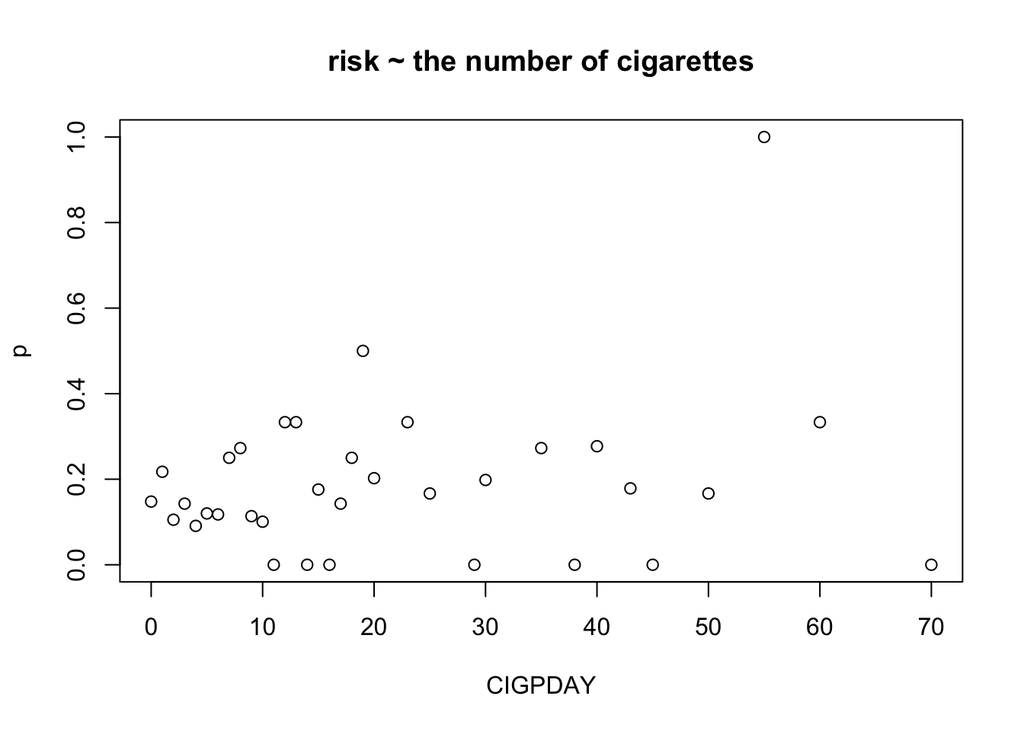

```r
q1=df %>% group_by(CIGPDAY) %>%
  summarise(n=n(),event=sum(MI_FCHD), p=sum(MI_FCHD)/n())

#the relationship between the probability of MI_FCHD and CIGPDAY
plot(p~CIGPDAY, data=q1, main="risk ~ the number of cigarettes")
```

```r
table(q1$n<10)
```

```
##
## FALSE  TRUE
##    19    15
```

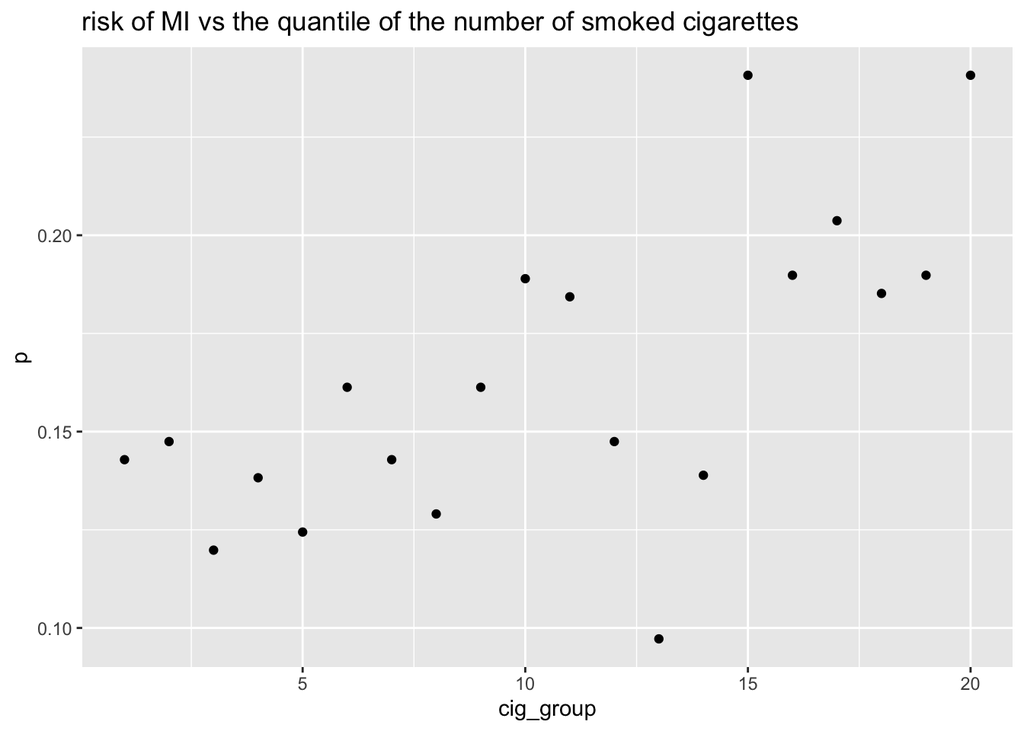

```r
#the relationship between the probability of MI_FCHD and quantile of CIGPDAY (20 groups)
df %>% mutate(cig_group = ntile(CIGPDAY, 20))%>%
  group_by(cig_group) %>%
  summarise(n=n(),event=sum(MI_FCHD), p=sum(MI_FCHD)/n()) %>%
  ggplot(aes(x=cig_group, y=p)) +
  geom_point()+
  ggtitle("risk of MI vs the quantile of the number of smoked cigarettes")
```

[output not shown]

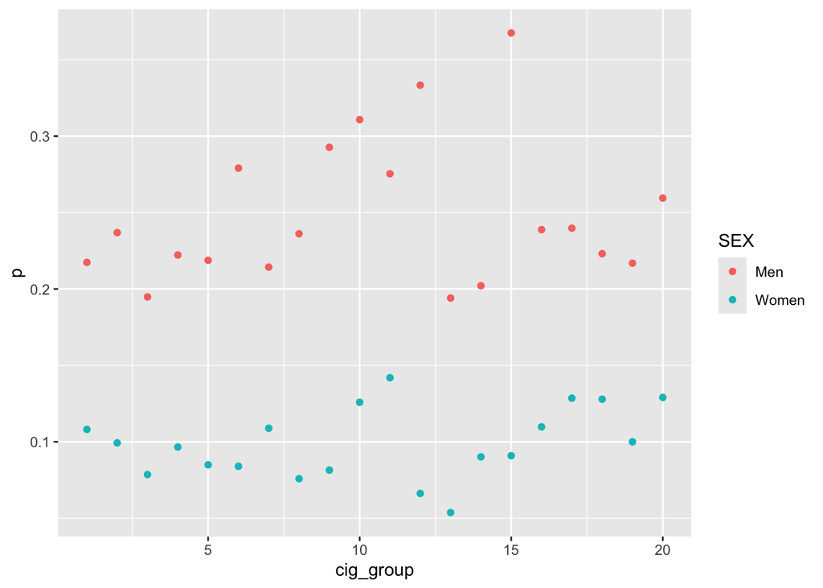

```r
#the relationship between the cigarettes and probability of MI_FCHD depending on sex
df %>% mutate(cig_group = ntile(CIGPDAY, 20)) %>%
  group_by(SEX,cig_group) %>%
  summarise(n=n(),event=sum(MI_FCHD), p=sum(MI_FCHD)/n()) %>%
  ggplot(aes(x=cig_group,y=p,color=SEX))+geom_point()
```

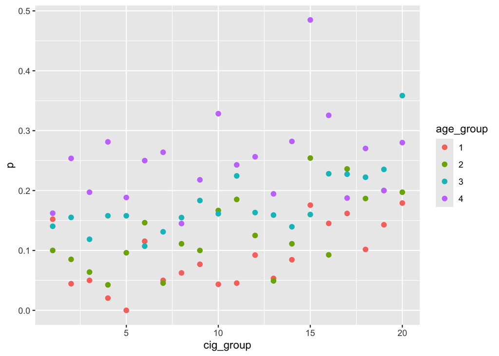

```r
#the relationship between the cigarettes and probability of MI_FCHD depending on age group
df %>% mutate(cig_group = ntile(CIGPDAY, 20))%>%
  mutate(age_group = as.factor(ntile(AGE, 4))) %>%
  group_by(age_group,cig_group) %>%
  summarise(n=n(),event=sum(MI_FCHD), p=sum(MI_FCHD)/n()) %>%
  ggplot(aes(x=cig_group,y=p,color=age_group))+geom_point(size=2)
```

[output not shown]

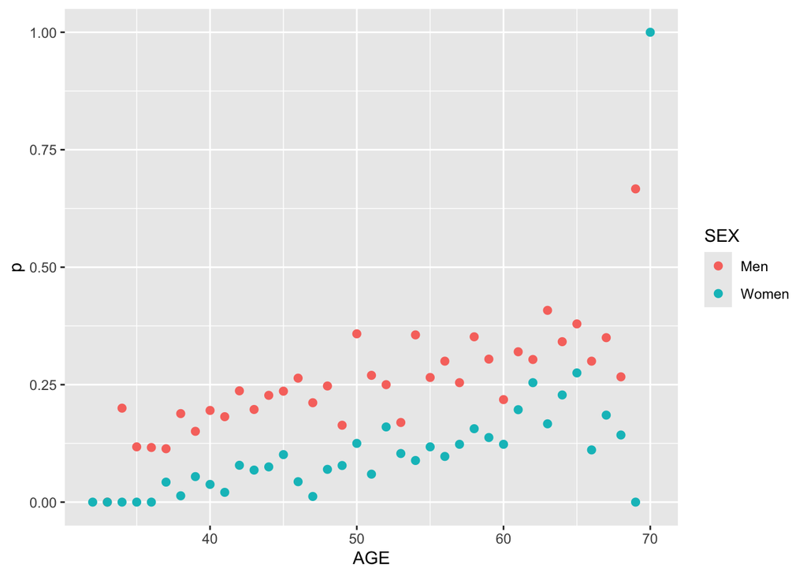

```r
#the relationship between the age and probability of MI_FCHD depending on sex
df %>% mutate(cig_group = ntile(CIGPDAY, 20)) %>%
  mutate(age_group = as.factor(ntile(AGE, 50))) %>%
  group_by(AGE,SEX) %>%
  summarise(n=n(),event=sum(MI_FCHD), p=sum(MI_FCHD)/n()) %>%
  ggplot(aes(x=AGE,y=p,color=SEX))+geom_point(size=2)
```

Insights:

The data is grouped based on the number of smoked cigarettes per day and further calculated the risk of having an event of hospitalised myocardial infarction or fatal coronary heart disease for each group.

There is a noticable large variability from the first plot, which might due to insufficient number of observations per group. Therefore, I further split the data based on the quantiles of the number of smoked cigarettes per day to ensure a sufficient number of observations in each group. And proceed to calculate the risk of myocardial infarction for each group. It is found that as the number of cigarettes smoked per day increases, the risk of having an event of hospitalised myocardial infarction or fatal coronary heart disease increases.

From the above plots, it was unclear on whether the relationship between the number of smoked cigarettes and the risk of hospitalised myocardial or fatal coronary heart disease depends on age and gender. It seems that the relationships between the risk of hospitalised myocardial or fatal coronary heart disease and age depends on gender.

### 1.3 Logistic Regression Analysis

```r
a4q1 = df %>% select(SEX, CIGPDAY, AGE, MI_FCHD, BMI) # a new data with selected variables

a4q1.gam = gam(MI_FCHD ~ s(CIGPDAY)+s(AGE), data=a4q1)
summary(a4q1.gam)$s.table
```

```
##            edf Ref.df         F p-value
## s(CIGPDAY)   1      1  44.53129       0
## s(AGE)       1      1 118.49357       0
```

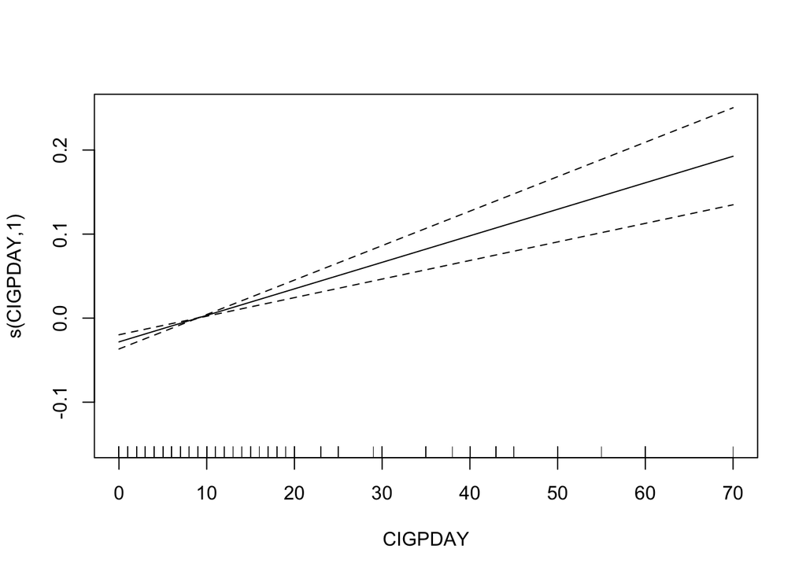

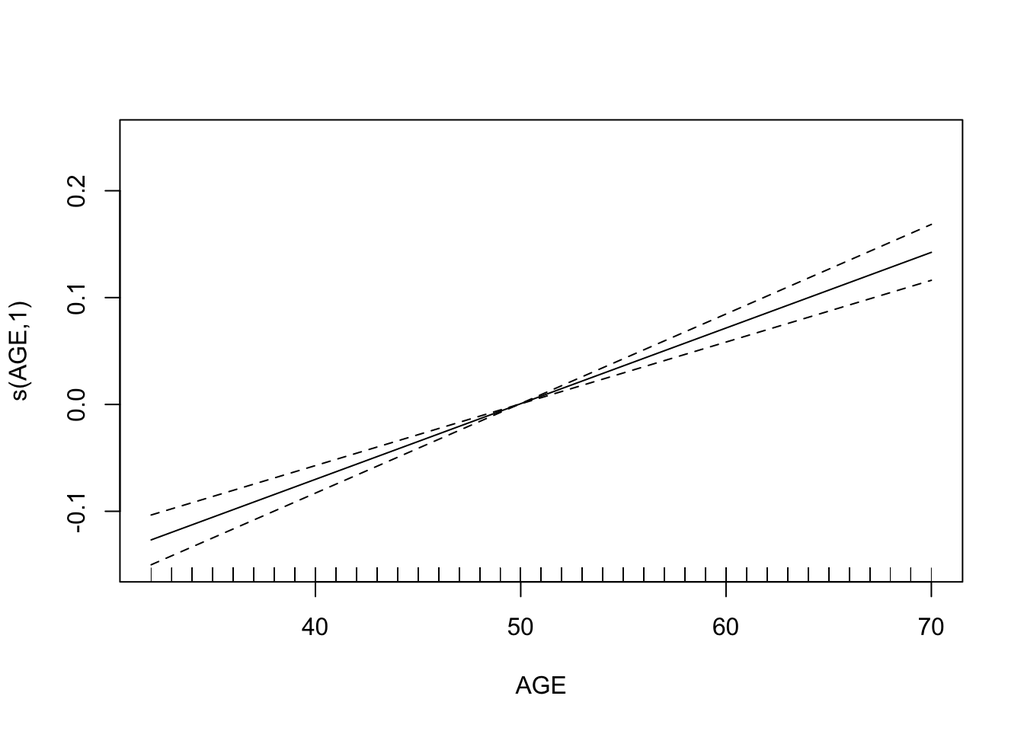

```r
plot(a4q1.gam) #all linear relationships
```

```r
detach('package:mgcv')

a4q1.glm <- glm(MI_FCHD~., family='binomial', data=a4q1)
a4q1.int.glm <- glm(MI_FCHD~CIGPDAY*AGE*SEX, family='binomial', data=a4q1)
summary(a4q1.int.glm)
```

```
##
## Call:
## glm(formula = MI_FCHD ~ CIGPDAY * AGE * SEX, family = "binomial",
##     data = a4q1)
##
## Coefficients:
##                        Estimate Std. Error z value Pr(>|z|)
## (Intercept)          -3.2173598  0.4458026  -7.217 5.31e-13 ***
## CIGPDAY               0.0220891  0.0236524   0.934 0.350354
## AGE                   0.0405771  0.0083593   4.854 1.21e-06 ***
## SEXWomen             -3.7613689  0.7419143  -5.070 3.98e-07 ***
## CIGPDAY:AGE          -0.0003513  0.0004644  -0.756 0.449397
## CIGPDAY:SEXWomen      0.0696030  0.0523924   1.328 0.184015
## AGE:SEXWomen          0.0471516  0.0134341   3.510 0.000448 ***
## CIGPDAY:AGE:SEXWomen -0.0009807  0.0010235  -0.958 0.337980
## ---
## Signif. codes:  0 '***' 0.001 '**' 0.01 '*' 0.05 '.' 0.1 ' ' 1
##
## (Dispersion parameter for binomial family taken to be 1)
##
##     Null deviance: 3861.5  on 4331  degrees of freedom
## Residual deviance: 3553.2  on 4324  degrees of freedom
## AIC: 3569.2
##
## Number of Fisher Scoring iterations: 5
```

```r
anova(a4q1.glm, a4q1.int.glm, test='Chisq') #evidence of interaction
```

```
## Analysis of Deviance Table
##
## Model 1: MI_FCHD ~ SEX + CIGPDAY + AGE + BMI
## Model 2: MI_FCHD ~ CIGPDAY * AGE * SEX
##   Resid. Df Resid. Dev Df Deviance Pr(>Chi)
## 1      4327     3540.3
## 2      4324     3553.2  3  -12.836
```

```r
options(na.action = "na.fail")
a4q1.fits <-dredge(a4q1.int.glm) #find possible models
```

```
## Fixed term is "(Intercept)"
```

```r
a4q1.fits[1:10,]
```

```
## Global model call: glm(formula = MI_FCHD ~ CIGPDAY * AGE * SEX, family = "binomial",
##     data = a4q1)
## ---
## Model selection table
##      (Int)     AGE      CIG SEX    AGE:CIG AGE:SEX CIG:SEX AGE:CIG:SEX df
## 56  -2.998 0.03638 0.004427   +                  +       +              6
## 64  -3.343 0.04297 0.032120   + -0.0005511       +       +              7
## 128 -3.217 0.04058 0.022090   + -0.0003513       +       +           +  8
## 24  -3.104 0.03751 0.008039   +                  +                      5
## 32  -3.437 0.04386 0.034040   + -0.0005154       +                      6
## 22  -2.872 0.03505            +                  +                      4
## 16  -4.253 0.05957 0.053270   + -0.0008923                              5
## 48  -4.264 0.06033 0.052260   + -0.0009142               +              6
## 8   -3.796 0.05092 0.008288   +                                         4
## 40  -3.792 0.05136 0.006286   +                          +              5
##        logLik   AICc delta weight
## 56  -1777.926 3567.9  0.00  0.342
## 64  -1777.046 3568.1  0.25  0.302
## 128 -1776.590 3569.2  1.34  0.175
## 24  -1780.268 3570.6  2.68  0.090
## 32  -1779.512 3571.0  3.17  0.070
## 22  -1782.823 3573.7  5.78  0.019
## 16  -1784.380 3578.8 10.90  0.001
## 48  -1783.547 3579.1 11.24  0.001
## 8   -1786.838 3581.7 13.81  0.000
## 40  -1786.116 3582.2 14.38  0.000
## Models ranked by AICc(x)
```

```r
#find the best model
model1 <-get.models(a4q1.fits, 1)[[1]]
hltest(model1) #no evidence against
```

```
##
##    The Hosmer-Lemeshow goodness-of-fit test
##
##  Group Size Observed   Expected
##      1  433        9  14.646482
##      2  428       23  22.062821
##      3  435       40  31.643655
##      4  445       42  45.767002
##      5  425       57  62.533263
##      6  428       81  77.145922
##      7  424       89  86.567878
##      8  434      109 101.106164
##      9  444      124 121.861700
##     10  433      135 144.427847
##     11    3        0   1.237266
##
##          Statistic =  9.79961
## degrees of freedom =  9
##            p-value =  0.36695
```

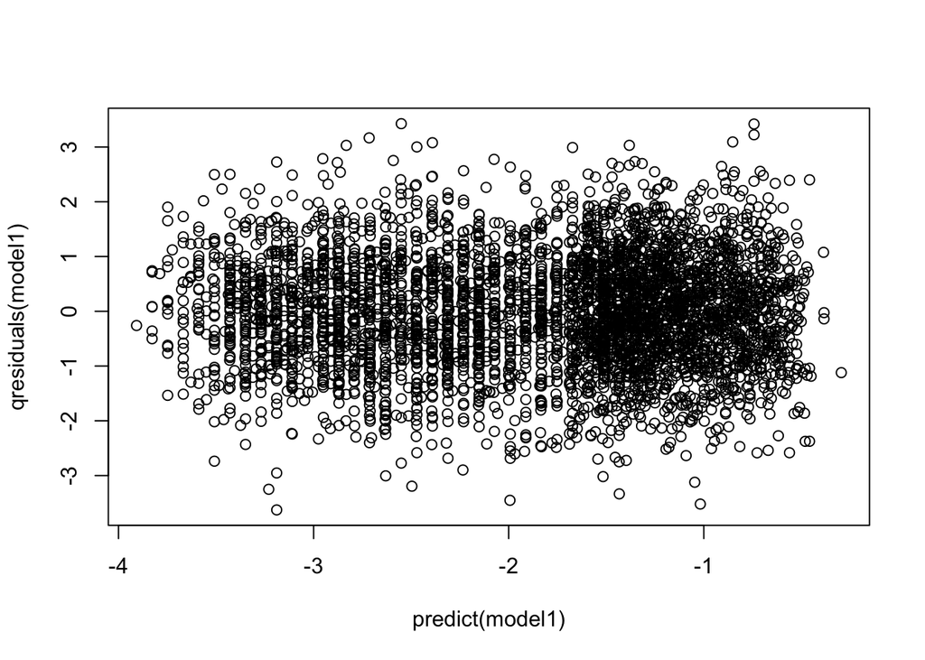

```r
plot(qresiduals(model1)~predict(model1)) #looks good
```

```r
summary(model1)
```

```
##
## Call:
## glm(formula = MI_FCHD ~ AGE + CIGPDAY + SEX + AGE:SEX + CIGPDAY:SEX +
##     1, family = "binomial", data = a4q1)
##
## Coefficients:
##                   Estimate Std. Error z value Pr(>|z|)
## (Intercept)      -2.998008   0.336176  -8.918  < 2e-16 ***
## AGE               0.036378   0.006223   5.846 5.03e-09 ***
## CIGPDAY           0.004427   0.003913   1.131   0.2580
## SEXWomen         -3.543774   0.604065  -5.867 4.45e-09 ***
## AGE:SEXWomen      0.043444   0.010848   4.005 6.21e-05 ***
## CIGPDAY:SEXWomen  0.019356   0.008785   2.203   0.0276 *
## ---
## Signif. codes:  0 '***' 0.001 '**' 0.01 '*' 0.05 '.' 0.1 ' ' 1
##
## (Dispersion parameter for binomial family taken to be 1)
##
##     Null deviance: 3861.5  on 4331  degrees of freedom
## Residual deviance: 3555.9  on 4326  degrees of freedom
## AIC: 3567.9
##
## Number of Fisher Scoring iterations: 5
```

```r
100*(exp(confint(model1))-1)
```

```
##                        2.5 %     97.5 %
## (Intercept)      -97.4335930 -90.408269
## AGE                2.4520727   4.983006
## CIGPDAY           -0.3280133   1.213780
## SEXWomen         -99.1260766 -90.657425
## AGE:SEXWomen       2.2551851   6.699424
## CIGPDAY:SEXWomen   0.1862143   3.701681
```

Insights:

After assumption checks, there are no evidence against the model and the residual plot looks reasonable.

It is found that the impact of the number of smoked cigarettes per day on the outcome depends on gender. For men, given the same age, the number of smoked cigarettes per day does not significantly affect the risk of having an event of hospitalized myocardial infarction or fatal coronary heart disease. However, given the same age, for women, the number of smoked cigarettes per day increases the risk of having an event of hospitalized MI of fatal CHD. For females, the odds of having an event of hospitalized MI of fatal CHD by between 0.186% and 3.70%.

## 2. Building a CHD Risk Prediction Model

The research aims to develop a risk prediction model for hospitalized myocardial infarction or fatal coronary heart disease using all collected variables.

Since the sample size of the data is reasonably large, I will randomly select 1000 samples to serve as the test set and use the remaining data to build prediction models.

```r
set.seed(1234)
test.index = sample(1:nrow(df), 1000)
FirstFram.tr = df[-test.index,]
FirstFram.te = df[test.index,]
summary(FirstFram.tr)
```

```
##      SEX               TOTCHOL           AGE           SYSBP
##  Length:3332        Min.   :113.0   Min.   :32.0   Min.   : 83.5
##  Class :character   1st Qu.:205.0   1st Qu.:42.0   1st Qu.:117.0
##  Mode  :character   Median :234.0   Median :49.0   Median :128.5
##                     Mean   :236.9   Mean   :49.9   Mean   :132.8
##                     3rd Qu.:264.0   3rd Qu.:57.0   3rd Qu.:144.0
##                     Max.   :696.0   Max.   :70.0   Max.   :295.0
##      DIABP           CIGPDAY            BMI           MI_FCHD
##  Min.   : 48.00   Min.   : 0.000   Min.   :15.54   Min.   :0.0000
##  1st Qu.: 75.00   1st Qu.: 0.000   1st Qu.:23.05   1st Qu.:0.0000
##  Median : 82.00   Median : 0.000   Median :25.41   Median :0.0000
##  Mean   : 83.04   Mean   : 9.066   Mean   :25.81   Mean   :0.1621
##  3rd Qu.: 90.00   3rd Qu.:20.000   3rd Qu.:28.05   3rd Qu.:0.0000
##  Max.   :142.50   Max.   :70.000   Max.   :51.28   Max.   :1.0000
```

```r
summary(FirstFram.te)
```

```
##      SEX               TOTCHOL           AGE           SYSBP
##  Length:1000        Min.   :129.0   Min.   :34.0   Min.   : 83.5
##  Class :character   1st Qu.:207.0   1st Qu.:43.0   1st Qu.:117.5
##  Mode  :character   Median :235.0   Median :49.0   Median :129.0
##                     Mean   :237.3   Mean   :49.9   Mean   :133.0
##                     3rd Qu.:265.0   3rd Qu.:57.0   3rd Qu.:144.0
##                     Max.   :432.0   Max.   :69.0   Max.   :213.0
##      DIABP           CIGPDAY            BMI           MI_FCHD
##  Min.   : 57.50   Min.   : 0.000   Min.   :17.11   Min.   :0.000
##  1st Qu.: 75.00   1st Qu.: 0.000   1st Qu.:23.29   1st Qu.:0.000
##  Median : 82.00   Median : 0.000   Median :25.50   Median :0.000
##  Mean   : 83.19   Mean   : 8.573   Mean   :25.92   Mean   :0.169
##  3rd Qu.: 90.00   3rd Qu.:20.000   3rd Qu.:28.14   3rd Qu.:0.000
##  Max.   :135.00   Max.   :60.000   Max.   :56.80   Max.   :1.000
```

### 2.1 Model Selection

```r
#AICc
df.glm = glm(MI_FCHD ~., family='binomial', data = FirstFram.tr)
df.fits <- dredge(df.glm)
print(df.fits[1:10, ])
```

```
## Global model call: glm(formula = MI_FCHD ~ ., family = "binomial", data = FirstFram.tr)
## ---
## Model selection table
##     (Intrc)     AGE     BMI    CIGPD     DIABP SEX   SYSBP    TOTCH df
## 128  -6.803 0.03036 0.02519 0.006661 -0.010130   + 0.01868 0.007399  8
## 120  -7.109 0.03276 0.02166 0.006853             + 0.01442 0.007346  7
## 124  -6.570 0.02813 0.02330          -0.010420   + 0.01889 0.007474  7
## 116  -6.879 0.03054 0.01959                      + 0.01451 0.007419  6
## 118  -6.673 0.03200         0.006148             + 0.01556 0.007470  6
## 114  -6.502 0.03007                              + 0.01553 0.007525  5
## 122  -6.196 0.02807                  -0.008412   + 0.01922 0.007586  6
## 126  -6.376 0.03002         0.005910 -0.008009   + 0.01907 0.007529  7
## 123  -5.499         0.02294          -0.017120   + 0.02505 0.007918  6
## 121  -5.139                          -0.015070   + 0.02535 0.008040  5
##        logLik   AICc delta weight
## 128 -1312.204 2640.5  0.00  0.197
## 120 -1313.430 2640.9  0.44  0.158
## 124 -1313.450 2640.9  0.48  0.155
## 116 -1314.751 2641.5  1.08  0.115
## 118 -1314.843 2641.7  1.26  0.105
## 114 -1315.914 2641.8  1.39  0.098
## 122 -1315.040 2642.1  1.65  0.086
## 126 -1314.054 2642.1  1.69  0.085
## 123 -1323.427 2658.9 18.43  0.000
## 121 -1324.971 2660.0 19.51  0.000
## Models ranked by AICc(x)
```

```r
#BIC
df.fits2 <- dredge(df.glm, rank="BIC")
print(df.fits2[1:10, ])
```

```
## Global model call: glm(formula = MI_FCHD ~ ., family = "binomial", data = FirstFram.tr)
## ---
## Model selection table
##     (Intrc)     AGE     BMI    CIGPD     DIABP SEX   SYSBP    TOTCH df
## 114  -6.502 0.03007                              + 0.01553 0.007525  5
## 116  -6.879 0.03054 0.01959                      + 0.01451 0.007419  6
## 118  -6.673 0.03200         0.006148             + 0.01556 0.007470  6
## 122  -6.196 0.02807                  -0.008412   + 0.01922 0.007586  6
## 120  -7.109 0.03276 0.02166 0.006853             + 0.01442 0.007346  7
## 124  -6.570 0.02813 0.02330          -0.010420   + 0.01889 0.007474  7
## 126  -6.376 0.03002         0.005910 -0.008009   + 0.01907 0.007529  7
## 113  -5.570                                      + 0.01914 0.007978  4
## 128  -6.803 0.03036 0.02519 0.006661 -0.010130   + 0.01868 0.007399  8
## 121  -5.139                          -0.015070   + 0.02535 0.008040  5
##        logLik    BIC delta weight
## 114 -1315.914 2672.4  0.00  0.864
## 116 -1314.751 2678.2  5.79  0.048
## 118 -1314.843 2678.4  5.97  0.044
## 122 -1315.040 2678.7  6.36  0.036
## 120 -1313.430 2683.6 11.26  0.003
## 124 -1313.450 2683.7 11.29  0.003
## 126 -1314.054 2684.9 12.50  0.002
## 113 -1327.951 2688.3 15.96  0.000
## 128 -1312.204 2689.3 16.91  0.000
## 121 -1324.971 2690.5 18.11  0.000
## Models ranked by BIC(x)
```

```r
options(na.action = "na.omit")
```

### 2.1 Model Evaluation

```r
options(width=66)
out = rep(0,20)
for (i in 1:20) {
  newpreds = predict(get.models(df.fits, i) [[1]],
                     newdata=FirstFram.te, type='response')
  my.roc = roc(response=FirstFram.te$MI_FCHD,
               predictor=newpreds, ci=TRUE, quiet=TRUE)
  out[i] = my.roc$auc
}
print(which.max(out)) #the first one
```

```
## [1] 2
```

```r
model2 = get.models(df.fits, 2)[[1]] #first model is chosen

#assumption check
hltest(model2) #no evidence against
```

```
##
##    The Hosmer-Lemeshow goodness-of-fit test
##
##  Group Size Observed   Expected
##      1  333        7   9.473229
##      2  333       11  15.358420
##      3  333       18  22.030637
##      4  333       35  30.272716
##      5  333       35  39.853551
##      6  333       65  50.964025
##      7  333       62  62.652549
##      8  333       82  76.186894
##      9  333       98  95.814228
##     10  333      126 135.809722
##     11    2        1   1.584030
##
##          Statistic =  11.68394
## degrees of freedom =  9
##            p-value =  0.23172
```

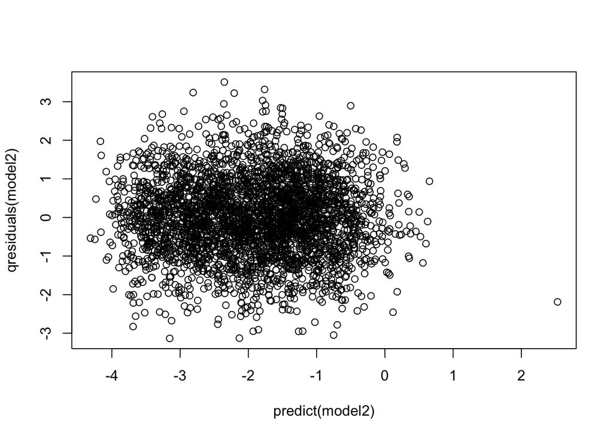

```r
plot(qresiduals(model2)~predict(model2)) #looks good
```

```r
summary(model2)
```

```
##
## Call:
## glm(formula = MI_FCHD ~ AGE + BMI + CIGPDAY + SEX + SYSBP + TOTCHOL +
##     1, family = "binomial", data = FirstFram.tr)
##
## Coefficients:
##              Estimate Std. Error z value Pr(>|z|)
## (Intercept) -7.109318   0.515998 -13.778  < 2e-16 ***
## AGE          0.032757   0.006310   5.191 2.09e-07 ***
## BMI          0.021662   0.012813   1.691   0.0909 .
## CIGPDAY      0.006853   0.004196   1.633   0.1025
## SEXWomen    -1.288041   0.111745 -11.527  < 2e-16 ***
## SYSBP        0.014424   0.002313   6.237 4.47e-10 ***
## TOTCHOL      0.007346   0.001115   6.589 4.43e-11 ***
## ---
## Signif. codes:  0 '***' 0.001 '**' 0.01 '*' 0.05 '.' 0.1 ' ' 1
##
## (Dispersion parameter for binomial family taken to be 1)
##
##     Null deviance: 2952.7  on 3331  degrees of freedom
## Residual deviance: 2626.9  on 3325  degrees of freedom
## AIC: 2640.9
##
## Number of Fisher Scoring iterations: 5
```

```r
model2.roc = roc(response = FirstFram.te$MI_FCHD,
                 predictor=predict(model2,newdata = FirstFram.te, type='response'),ci='TRUE')
model2.roc
```

```
##
## Call:
## roc.default(response = FirstFram.te$MI_FCHD, predictor = predict(model2,     newdata = FirstFram.te, type = "response"), ci = "TRUE")
##
## Data: predict(model2, newdata = FirstFram.te, type = "response") in 831 controls (FirstFram.te$MI_FCHD 0) < 169 cases (FirstFram.te$MI_FCHD 1).
## Area under the curve: 0.7583
## 95% CI: 0.721-0.7955 (DeLong)
```

Final Model:

$log(p_i/1-p_i) = \beta_0 + \beta_1 \times AGE_i + \beta_2 \times BMI_i+\beta_3 \times CIGPDAY_i + \beta_4 \times SEXWomen_i +\beta_5 \times SYSBP_i + \beta_6 \times TOTCHOL_i$

where $Y_i \sim Binomial(1, p_i)$

$AGE_i$ is the age at exam for ith participant; $BMI_i$ is the Body Mass Index of the ith participant; $CIGPDAY_i$ is the number of cigarettes smoked each day for the ith particpant; $SEXWomen_i$ =1 when the ith participant is a women; $SYSBP_i$ is the systolic blood pressure of the ith participant; $TOTCHOL_i$ is the serum total cholesterol of the ith participant; $p_i$ is the probability that the ith participant has hospitalised myocardial infarction or fatal coronary heart disease.

Based on AUC, it is recommended to use the 2nd model for prediction. Its estimated AUC is 0.721-0.7955 (95% confidence interval)

## 3. Classification

```r
pred = predict(model2,newdata = FirstFram.te, type='response')
predict = ifelse(pred <= 0.2, 0, 1)
conf_matrix=table(predict,FirstFram.te$MI_FCHD )

library(caret)
sensitivity(conf_matrix) #sensitivity
```

```
## [1] 0.7509025
```

```r
specificity(conf_matrix) #specificty
```

```
## [1] 0.6094675
```

```r
1-(sum(diag(conf_matrix))/sum(conf_matrix))#prediction error
```

```
## [1] 0.273
```

## Conclusion

This study examined the relationship between smoking and the risk of hospitalised myocardial infarction (MI) or fatal coronary heart disease (CHD) while considering the roles of gender, age, and BMI. The analysis showed that as the number of cigarettes smoked per day increases, the risk of CHD generally increases. However, when analysing the impact by gender, a significant interaction was observed: for women, smoking was associated with a higher risk of CHD, with odds increasing between 0.186% and 3.70%, whereas for men, smoking did not have a statistically significant effect.